# Simple Line Plots

Perhaps the simplest of all plots is the visualization of a single function $y = f(x)$. Here we will take a first look at creating a simple plot of this type. As with all the following sections, we'll start by setting up the notebook for plotting and importing the packages we will use:

```python
%matplotlib inline
import matplotlib.pyplot as plt
plt.style.use('seaborn-whitegrid')
import numpy as np
```

對於所有Matplotlib圖，我們首先創建一個圖形和座標軸。 在最簡單的形式中，可以按如下方式創建圖形座標和軸：

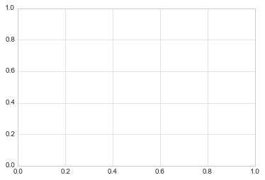

```python
fig = plt.figure()
ax = plt.axes()
```

在Matplotlib中， *figure* （類別“plt.Figure``”的實例）可以被認為是一個包含代表軸，圖形，文本和標籤的所有物件的單個容器。

- axes *（類別`plt.Axes`的一個實例）就是我們在上面看到的：帶有刻度和標籤的邊界框，最終將包含組成我們視覺化的繪圖元素。 一旦創建了一個軸，就可以使用`ax.plot`函數來繪製一些資料。 如下圖就是簡單的正弦曲線：

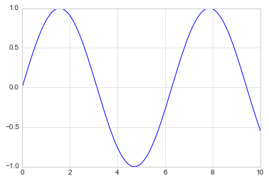

```python
fig = plt.figure()
ax = plt.axes()

x = np.linspace(0, 10, 1000)
ax.plot(x, np.sin(x));
```

也可以使用pylab介面，在後臺創建圖形和軸

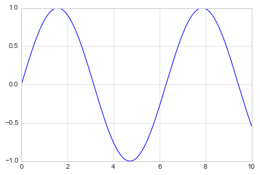

```python
plt.plot(x, np.sin(x));
```

如果我們想要創建一個包含多行的單個圖形，我們可以簡單地多次呼叫`plot`函數：

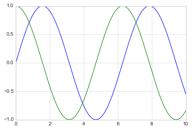

```python
plt.plot(x, np.sin(x))
plt.plot(x, np.cos(x));
```

## 調整圖的線條顏色和樣式

`plt.plot（）`函數接受可用於指定線條顏色和樣式參數的其他參數。 要調整顏色，可以使用`color`關鍵字，該關鍵字接受表示幾乎任何可以想像的顏色的字串參數。 顏色可以通過多種方式指定：

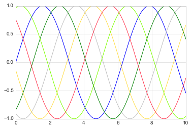

```python
plt.plot(x, np.sin(x - 0), color='blue')        # 利用name指定顏色
plt.plot(x, np.sin(x - 1), color='g')           # 利用簡短顏色碼(rgbcmyk)
plt.plot(x, np.sin(x - 2), color='0.75')        # 灰階(Grayscale)介於0與1之間
plt.plot(x, np.sin(x - 3), color='#FFDD44')     # 利用十六進位碼 (RRGGBB from 00 to FF)
plt.plot(x, np.sin(x - 4), color=(1.0,0.2,0.3)) # 利用RGB元組, 三原色的值都是從0到1
plt.plot(x, np.sin(x - 5), color='chartreuse'); # 也支援所有HTML顏色名稱
```

如果未指定顏色，Matplotlib將自動迴圈顯示多行的一組默認顏色。

同樣，可以使用`linestyle`關鍵字調整線條樣式：

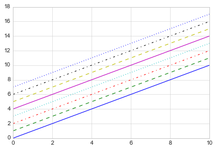

```python
plt.plot(x, x + 0, linestyle='solid')
plt.plot(x, x + 1, linestyle='dashed')
plt.plot(x, x + 2, linestyle='dashdot')
plt.plot(x, x + 3, linestyle='dotted');

# For short, you can use the following codes:
plt.plot(x, x + 4, linestyle='-')  # solid
plt.plot(x, x + 5, linestyle='--') # dashed
plt.plot(x, x + 6, linestyle='-.') # dashdot
plt.plot(x, x + 7, linestyle=':');  # dotted
```

這些`linestyle`和`color`代碼也可以合併為`plt.plot（）`函數的非關鍵字參數：

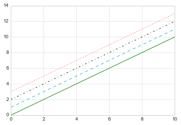

```python
plt.plot(x, x + 0, '-g')  # solid green
plt.plot(x, x + 1, '--c') # dashed cyan
plt.plot(x, x + 2, '-.k') # dashdot black
plt.plot(x, x + 3, ':r');  # dotted red
```

這些單字元顏色代碼反映了RGB（紅色/綠色/藍色）和CMYK（青色/品紅色/黃色/黑色/黑色）顏色系統中的標準縮寫，通常用於數位彩色圖形。

## 調整圖中座標軸限制

調整座標軸限制的最基本方法是使用`plt.xlim（）`和`plt.ylim（）`方法：

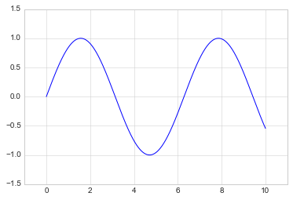

```python
plt.plot(x, np.sin(x))

plt.xlim(-1, 11)
plt.ylim(-1.5, 1.5);
```

若要反向顯示任一軸，可以顛倒參數的順序：

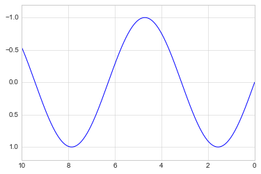

```python
plt.plot(x, np.sin(x))

plt.xlim(10, 0)
plt.ylim(1.2, -1.2);
```

`plt.axis（）`方法允許通過一次呼叫來設置`x`和`y`限制，通過一個指定`[xmin,xmax,ymin,ymax]的串列`：

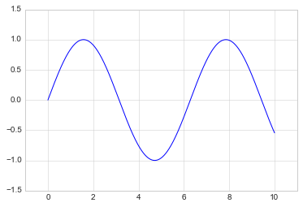

```python
plt.plot(x, np.sin(x))
plt.axis([-1, 11, -1.5, 1.5]);
```

`plt.axis（）`方法甚至允許自動收緊當前圖周圍的界限：

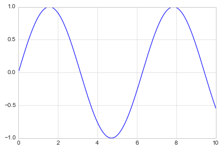

```python
plt.plot(x, np.sin(x))
plt.axis('tight');
```

也可以確保相等的寬高比，以便在螢幕上，“x”中的一個單位等於“y”中的一個單位：

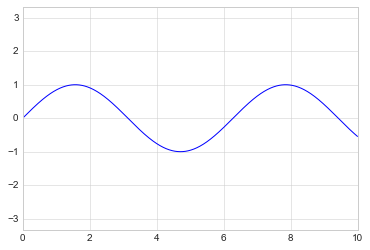

```python
plt.plot(x, np.sin(x))
plt.axis('equal');
```

## 圖的標記

圖表的標籤：標題，軸標籤和簡單圖例。

標題和軸標籤是最簡單的標籤 - 有一些方法可用於快速設置它們：

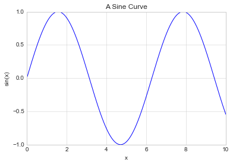

```python
plt.plot(x, np.sin(x))
plt.title("A Sine Curve")
plt.xlabel("x")
plt.ylabel("sin(x)");
```

可以使用函數的可選參數調整這些標籤的位置，大小和樣式。

當在單個軸中顯示多條線時，創建標記每種線類型的圖例是很有用的。 同樣，Matplotlib的`plt.legend（）`方法完成，使用plot函數的`label`關鍵字指定每行的標籤：

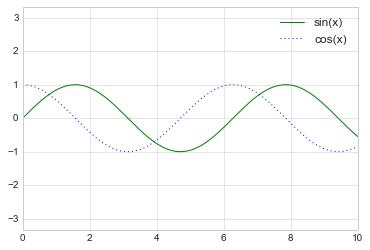

```python
plt.plot(x, np.sin(x), '-g', label='sin(x)')
plt.plot(x, np.cos(x), ':b', label='cos(x)')
plt.axis('equal')

plt.legend();
```

`plt.legend（）`函數跟蹤線條樣式和顏色，並將它們與正確的標籤相匹配。